# narsc_regression_analysis

## gini 2000-2010

Run models with simple difference as DV.

```r
# exec models
m1 <- lm('gini_diff_0010 ~ ppctchg_0010' , data=data)

m1 <- lm('gini_diff_0010 ~ ppctchg_0010' , data=data)

m2 <- lm('gini_diff_0010 ~ ppctchg_0010 + STATE + metro_status00 + pwhite_00 + log(pop00)' , data=data)

m3 <- lm('gini_diff_0010 ~ ppctchg_0010 + STATE + metro_status00 + pwhite_00 + log(pop00) + gini_00' , data=data)

m4 <- lm('gini_diff_0010 ~ ppctchg_0010 + STATE + pwhite_00 + gini_00 + code2003' , data=data)

m5 <- lm('gini_diff_0010 ~ loss_dummy_0010' , data=data)

m6 <- lm('gini_diff_0010 ~ loss_dummy_0010 + STATE + metro_status00 + pwhite_00 + log(pop00)' , data=data)

m7 <- lm('gini_diff_0010 ~ loss_dummy_0010 + STATE + metro_status00 + pwhite_00 + log(pop00) + gini_00' , data=data)

m8 <- lm('gini_diff_0010 ~ loss_dummy_0010 + STATE + pwhite_00 + gini_00 + code2003' , data=data)

cov1 <- vcovHC(m1, type = "HC3")
robust_se1 <- sqrt(diag(cov1))

cov2 <- vcovHC(m2, type = "HC3")
robust_se2 <- sqrt(diag(cov2))

cov3 <- vcovHC(m3, type = "HC3")
robust_se3 <- sqrt(diag(cov3))

cov4 <- vcovHC(m4, type = "HC3")
robust_se4 <- sqrt(diag(cov4))

cov5 <- vcovHC(m5, type = "HC3")
robust_se5 <- sqrt(diag(cov5))

cov6 <- vcovHC(m6, type = "HC3")
robust_se6 <- sqrt(diag(cov6))

cov7 <- vcovHC(m7, type = "HC3")
robust_se7 <- sqrt(diag(cov7))

cov8 <- vcovHC(m8, type = "HC3")
robust_se8 <- sqrt(diag(cov8))

stargazer(m1, m2, m3, m4, m5, m6, m7, m8,
          type='text',
          omit = c('STATE'), omit.stat = c("f", "ser"),
          se = list(robust_se1, robust_se2, robust_se3, robust_se4, robust_se5, robust_se6, robust_se7, robust_se8),
          dep.var.labels = 'gini diff 2010-2000')
```

```
##
## ================================================================================================
##                                                Dependent variable:
##                  -------------------------------------------------------------------------------
##                                                gini diff 2010-2000
##                     (1)       (2)       (3)       (4)       (5)       (6)       (7)       (8)
## ------------------------------------------------------------------------------------------------
## ppctchg_0010     0.0003*** 0.0001***  0.00002  0.0001***
##                  (0.00003) (0.00004) (0.00003) (0.00004)
##
## metro_status001            0.006***  0.004***                      0.007***  0.004***
##                             (0.001)   (0.001)                       (0.001)   (0.001)
##
## pwhite_00                   0.009**  -0.010*** -0.013***           0.011***  -0.010*** -0.013***
##                             (0.004)   (0.004)   (0.004)             (0.004)   (0.004)   (0.004)
##
## log(pop00)                 0.004***  0.005***                      0.004***  0.005***
##                             (0.001)  (0.0005)                       (0.001)  (0.0005)
##
## gini_00                              -0.299*** -0.265***                     -0.301*** -0.273***
##                                       (0.021)   (0.022)                       (0.021)   (0.021)
##
## code20032                                      -0.004***                               -0.005***
##                                                 (0.001)                                 (0.001)
##
## code20033                                      -0.006***                               -0.007***
##                                                 (0.001)                                 (0.001)
##
## code20034                                      -0.007***                               -0.007***
##                                                 (0.001)                                 (0.001)
##
## code20035                                      -0.009***                               -0.009***
##                                                 (0.002)                                 (0.002)
##
## code20036                                      -0.012***                               -0.013***
##                                                 (0.001)                                 (0.001)
##
## code20037                                      -0.012***                               -0.013***
##                                                 (0.001)                                 (0.001)
##
## code20038                                      -0.015***                               -0.016***
##                                                 (0.002)                                 (0.002)
##
## code20039                                      -0.014***                               -0.015***
##                                                 (0.002)                                 (0.002)
##
## loss_dummy_00101                                         -0.005***  -0.001    -0.001   -0.002**
##                                                           (0.001)   (0.001)   (0.001)   (0.001)
##
## Constant         0.019***  -0.038*** 0.107***  0.151***  0.022***  -0.041*** 0.108***  0.157***
##                  (0.0004)   (0.007)   (0.012)   (0.012)  (0.0005)   (0.007)   (0.012)   (0.011)
##
## ------------------------------------------------------------------------------------------------
## Observations       3,104     3,104     3,104     3,104     3,104     3,104     3,104     3,104
## R2                 0.030     0.193     0.267     0.233     0.014     0.189     0.267     0.233
## Adjusted R2        0.030     0.179     0.255     0.219     0.014     0.175     0.255     0.218
## ================================================================================================
## Note:                                                                *p<0.1; **p<0.05; ***p<0.01
```

Note that including starting year Gini makes pop change insignificant in M3, but it again becomes significant when switching out metro status and base pop. for USDA rural-urban codes. The same is true for the dummy variable for loss.

**Change DV to diff in growth rate**

```r
# exec models
m1 <- lm('grate_diff_00125 ~ ppctchg_0010' , data=data)

m1 <- lm('grate_diff_00125 ~ ppctchg_0010' , data=data)

m2 <- lm('grate_diff_00125 ~ ppctchg_0010 + STATE + metro_status00 + pwhite_00 + log(pop00)' , data=data)

m3 <- lm('grate_diff_00125 ~ ppctchg_0010 + STATE + metro_status00 + pwhite_00 + log(pop00) + gini_00' , data=data)

m4 <- lm('grate_diff_00125 ~ ppctchg_0010 + STATE + pwhite_00 + gini_00 + code2003' , data=data)

m5 <- lm('grate_diff_00125 ~ loss_dummy_0010' , data=data)

m6 <- lm('grate_diff_00125 ~ loss_dummy_0010 + STATE + metro_status00 + pwhite_00 + log(pop00)' , data=data)

m7 <- lm('grate_diff_00125 ~ loss_dummy_0010 + STATE + metro_status00 + pwhite_00 + log(pop00) + gini_00' , data=data)

m8 <- lm('grate_diff_00125 ~ loss_dummy_0010 + STATE + pwhite_00 + gini_00 + code2003' , data=data)

cov1 <- vcovHC(m1, type = "HC3")
robust_se1 <- sqrt(diag(cov1))

cov2 <- vcovHC(m2, type = "HC3")
robust_se2 <- sqrt(diag(cov2))

cov3 <- vcovHC(m2, type = "HC3")
robust_se3 <- sqrt(diag(cov3))

cov4 <- vcovHC(m2, type = "HC3")
robust_se4 <- sqrt(diag(cov4))

cov5 <- vcovHC(m5, type = "HC3")
robust_se5 <- sqrt(diag(cov5))

cov6 <- vcovHC(m6, type = "HC3")
robust_se6 <- sqrt(diag(cov6))

cov7 <- vcovHC(m6, type = "HC3")
robust_se7 <- sqrt(diag(cov7))

cov8 <- vcovHC(m8, type = "HC3")
robust_se8 <- sqrt(diag(cov8))

stargazer(m1, m2, m3, m4, m5, m6, m7, m8,
          type='text',
          omit = c('STATE'), omit.stat = c("f", "ser"),
          se = list(robust_se1, robust_se2, robust_se3, robust_se4, robust_se5, robust_se6, robust_se7),
          dep.var.labels = 'gini growth rate diff 2010-2000')
```

```
##
## ================================================================================================
##                                                Dependent variable:
##                  -------------------------------------------------------------------------------
##                                          gini growth rate diff 2010-2000
##                    (1)       (2)       (3)       (4)       (5)       (6)       (7)       (8)
## ------------------------------------------------------------------------------------------------
## ppctchg_0010     0.069*** 0.039***    0.006   0.024***
##                  (0.007)   (0.008)   (0.008)   (0.008)
##
## metro_status001           1.419***  1.004***                      1.644***  1.031***
##                            (0.242)   (0.242)                       (0.239)   (0.239)
##
## pwhite_00                 2.385***  -2.690*** -3.410***           2.897***  -2.675*** -3.348***
##                            (0.813)   (0.813)   (0.813)             (0.808)   (0.808)   (0.653)
##
## log(pop00)                0.756***  0.990***                      0.831***  0.995***
##                            (0.117)   (0.117)                       (0.119)   (0.119)
##
## gini_00                              -80.703   -73.054                       -81.231  -74.886***
##                                                                                        (3.934)
##
## code20032                                      -1.037                                 -1.161***
##                                                                                        (0.346)
##
## code20033                                      -1.530                                 -1.677***
##                                                                                        (0.336)
##
## code20034                                      -1.593                                 -1.768***
##                                                                                        (0.387)
##
## code20035                                      -2.049                                 -2.217***
##                                                                                        (0.518)
##
## code20036                                      -2.880                                 -3.072***
##                                                                                        (0.303)
##
## code20037                                      -2.837                                 -3.029***
##                                                                                        (0.340)
##
## code20038                                      -3.454                                 -3.655***
##                                                                                        (0.390)
##
## code20039                                      -3.306                                 -3.505***
##                                                                                        (0.364)
##
## loss_dummy_00101                                        -1.192***  -0.335    -0.119    -0.490**
##                                                          (0.198)   (0.219)   (0.219)   (0.198)
##
## Constant         4.004*** -8.621*** 30.415*** 40.199*** 4.782***  -9.566*** 30.666*** 41.474***
##                  (0.102)   (1.532)   (1.532)   (1.532)   (0.110)   (1.578)   (1.578)   (2.128)
##
## ------------------------------------------------------------------------------------------------
## Observations      3,104     3,104     3,104     3,104     3,104     3,104     3,104     3,104
## R2                0.031     0.199     0.297     0.268     0.012     0.193     0.297     0.267
## Adjusted R2       0.031     0.185     0.285     0.254     0.012     0.180     0.285     0.253
## ================================================================================================
## Note:                                                                *p<0.1; **p<0.05; ***p<0.01
```

**Interpretation:** M1 indicates a 10 percentage point increase in population is associated with a 0.69 positive difference in county’s growth rate relative to the US. Since growth rate is equal to percent increase t1 to t2, this value is equivalent to the percentage point difference between a given county and the U.S. The bivariate model with the dummy for loss indicates switching from growth to loss status is associated with a 1.192 percentage point lower growth rate relative to the U.S. Recall the growth rate fo the US during this period is 5.94. After including controls, the comparable association drops to a 0.49 percentage point difference.

## gini 1990-2000

```r
# exec models
m1 <- lm('gini_diff_9000 ~ ppctchg_9000' , data=data)

m1 <- lm('gini_diff_9000 ~ ppctchg_9000' , data=data)

m2 <- lm('gini_diff_9000 ~ ppctchg_9000 + STATE + metro_status00 + pwhite_90 + log(pop00)' , data=data)

m3 <- lm('gini_diff_9000 ~ ppctchg_9000 + STATE + metro_status00 + pwhite_90 + log(pop00) + gini_90' , data=data)

m4 <- lm('gini_diff_9000 ~ ppctchg_9000 + STATE + pwhite_90 + gini_90 + code1993' , data=data)

m5 <- lm('gini_diff_9000 ~ loss_dummy_9000' , data=data)

m6 <- lm('gini_diff_9000 ~ loss_dummy_9000 + STATE + metro_status00 + pwhite_90 + log(pop00)' , data=data)

m7 <- lm('gini_diff_9000 ~ loss_dummy_9000 + STATE + metro_status00 + pwhite_90 + log(pop00) + gini_90' , data=data)

m8 <- lm('gini_diff_9000 ~ loss_dummy_9000 + STATE + pwhite_90 + gini_90 + code1993' , data=data)

cov1 <- vcovHC(m1, type = "HC3")
robust_se1 <- sqrt(diag(cov1))

cov2 <- vcovHC(m2, type = "HC3")
robust_se2 <- sqrt(diag(cov2))

cov3 <- vcovHC(m3, type = "HC3")
robust_se3 <- sqrt(diag(cov3))

cov4 <- vcovHC(m4, type = "HC3")
robust_se4 <- sqrt(diag(cov4))

cov5 <- vcovHC(m5, type = "HC3")
robust_se5 <- sqrt(diag(cov5))

cov6 <- vcovHC(m6, type = "HC3")
robust_se6 <- sqrt(diag(cov6))

cov7 <- vcovHC(m7, type = "HC3")
robust_se7 <- sqrt(diag(cov7))

cov8 <- vcovHC(m8, type = "HC3")
robust_se8 <- sqrt(diag(cov8))

stargazer(m1, m2, m3, m4, m5, m6, m7, m8,
          type='text',
          omit = c('STATE'), omit.stat = c("f", "ser"),
          se = list(robust_se1, robust_se2, robust_se3, robust_se4, robust_se5, robust_se6, robust_se7, robust_se8),
          dep.var.labels = 'gini diff 2000-1990')
```

```
##
## =================================================================================================
##                                                Dependent variable:
##                  --------------------------------------------------------------------------------
##                                                gini diff 2000-1990
##                     (1)       (2)       (3)        (4)        (5)      (6)       (7)       (8)
## -------------------------------------------------------------------------------------------------
## ppctchg_9000     0.00004** -0.0001** -0.0002*** -0.0001***
##                  (0.00002) (0.00003) (0.00002)  (0.00002)
##
## metro_status001            0.003***   -0.0003                        0.003***  -0.001
##                             (0.001)   (0.001)                        (0.001)   (0.001)
##
## pwhite_90                   -0.002   -0.026***  -0.026***             -0.003  -0.027*** -0.027***
##                             (0.003)   (0.003)    (0.003)             (0.003)   (0.003)   (0.003)
##
## log(pop00)                  0.001**   0.002***                        0.001*  0.002***
##                            (0.0004)   (0.0004)                       (0.0004) (0.0004)
##
## gini_90                              -0.357***  -0.353***                     -0.342*** -0.344***
##                                       (0.017)    (0.017)                       (0.017)   (0.017)
##
## code19931                                       -0.011***                               -0.012***
##                                                  (0.002)                                 (0.002)
##
## code19932                                       -0.009***                               -0.009***
##                                                  (0.001)                                 (0.001)
##
## code19933                                       -0.007***                               -0.006***
##                                                  (0.001)                                 (0.001)
##
## code19934                                       -0.007***                               -0.006***
##                                                  (0.001)                                 (0.001)
##
## code19935                                       -0.005***                               -0.004**
##                                                  (0.002)                                 (0.002)
##
## code19936                                       -0.011***                               -0.010***
##                                                  (0.001)                                 (0.001)
##
## code19937                                       -0.009***                               -0.008***
##                                                  (0.001)                                 (0.001)
##
## code19938                                       -0.011***                               -0.011***
##                                                  (0.001)                                 (0.001)
##
## code19939                                       -0.008***                               -0.007***
##                                                  (0.001)                                 (0.001)
##
## loss_dummy_90001                                           -0.002***  0.0002  0.003***    0.001
##                                                             (0.001)  (0.001)   (0.001)   (0.001)
##
## Constant         0.012***   0.010*    0.180***   0.206***  0.013***   0.012*  0.176***  0.201***
##                  (0.0004)   (0.006)   (0.010)    (0.009)   (0.0003)  (0.006)   (0.010)   (0.009)
##
## -------------------------------------------------------------------------------------------------
## Observations       3,103     3,103     3,103      3,103      3,103    3,103     3,103     3,103
## R2                 0.002     0.155     0.343      0.351      0.003    0.154     0.331     0.344
## Adjusted R2        0.001     0.141     0.332      0.338      0.003    0.140     0.319     0.331
## =================================================================================================
## Note:                                                                 *p<0.1; **p<0.05; ***p<0.01
```

**Interpretation:** In the 1990-2000 period, pop growth has a negative association with change in Gini after including controls. This is the opposite of results for 2000-2010/2012. The coefficients for the dummy variables also switch signs after including controls. The plot below shows the slope of the line in the bivariate regression plot is shallower in this period. Including controls tips it downward.

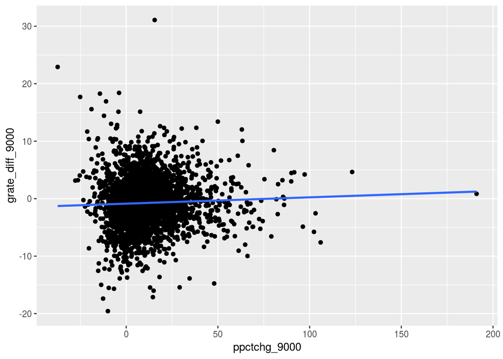

```r
# plot diff in growth rate 1990-2000 against percent pop change
data %>%
  ggplot(aes(y = grate_diff_9000, x = ppctchg_9000)) +
  geom_point() +
  geom_smooth(method = "lm", fill = NA)
```

**Switch DV**

```r
# exec models
m1 <- lm('grate_diff_9000 ~ ppctchg_9000' , data=data)

m1 <- lm('grate_diff_9000 ~ ppctchg_9000' , data=data)

m2 <- lm('grate_diff_9000 ~ ppctchg_9000 + STATE + metro_status00 + pwhite_90 + log(pop00)' , data=data)

m3 <- lm('grate_diff_9000 ~ ppctchg_9000 + STATE + metro_status00 + pwhite_90 + log(pop00) + gini_90' , data=data)

m4 <- lm('grate_diff_9000 ~ ppctchg_9000 + STATE + pwhite_90 + gini_90 + code1993' , data=data)

m5 <- lm('grate_diff_9000 ~ loss_dummy_9000' , data=data)

m6 <- lm('grate_diff_9000 ~ loss_dummy_9000 + STATE + metro_status00 + pwhite_90 + log(pop00)' , data=data)

m7 <- lm('grate_diff_9000 ~ loss_dummy_9000 + STATE + metro_status00 + pwhite_90 + log(pop00) + gini_90' , data=data)

m8 <- lm('grate_diff_9000 ~ loss_dummy_9000 + STATE + pwhite_90 + gini_90 + code1993' , data=data)

cov1 <- vcovHC(m1, type = "HC3")
robust_se1 <- sqrt(diag(cov1))

cov2 <- vcovHC(m2, type = "HC3")
robust_se2 <- sqrt(diag(cov2))

cov3 <- vcovHC(m3, type = "HC3")
robust_se3 <- sqrt(diag(cov3))

cov4 <- vcovHC(m4, type = "HC3")
robust_se4 <- sqrt(diag(cov4))

cov5 <- vcovHC(m5, type = "HC3")
robust_se5 <- sqrt(diag(cov5))

cov6 <- vcovHC(m6, type = "HC3")
robust_se6 <- sqrt(diag(cov6))

cov7 <- vcovHC(m7, type = "HC3")
robust_se7 <- sqrt(diag(cov7))

cov8 <- vcovHC(m8, type = "HC3")
robust_se8 <- sqrt(diag(cov8))

stargazer(m1, m2, m3, m4, m5, m6, m7, m8,
          type='text',
          omit = c('STATE'), omit.stat = c("f", "ser"),
          se = list(robust_se1, robust_se2, robust_se3, robust_se4, robust_se5, robust_se6, robust_se7, robust_se8),
          dep.var.labels = 'gini growth ratediff 2000-1990')
```

```
##
## ==================================================================================================
##                                                 Dependent variable:
##                  ---------------------------------------------------------------------------------
##                                           gini growth ratediff 2000-1990
##                     (1)      (2)       (3)        (4)        (5)      (6)       (7)        (8)
## --------------------------------------------------------------------------------------------------
## ppctchg_9000      0.011**   -0.010  -0.041***  -0.030***
##                   (0.005)  (0.007)   (0.006)    (0.006)
##
## metro_status001            0.914***   0.030                         0.877***   -0.101
##                            (0.228)   (0.184)                        (0.225)   (0.187)
##
## pwhite_90                   -0.059  -6.368***  -6.323***             -0.252  -6.743***  -6.604***
##                            (0.780)   (0.740)    (0.745)             (0.757)   (0.740)    (0.743)
##
## log(pop00)                  0.106    0.349***                        0.077    0.280***
##                            (0.113)   (0.086)                        (0.115)   (0.088)
##
## gini_90                             -93.382*** -92.748***                    -89.886*** -90.616***
##                                      (4.065)    (4.033)                       (4.037)    (4.022)
##
## code19931                                      -2.547***                                -2.828***
##                                                 (0.365)                                  (0.371)
##
## code19932                                      -2.103***                                -2.057***
##                                                 (0.282)                                  (0.283)
##
## code19933                                      -1.683***                                -1.544***
##                                                 (0.322)                                  (0.321)
##
## code19934                                      -1.743***                                -1.536***
##                                                 (0.336)                                  (0.334)
##
## code19935                                      -1.254***                                -1.042***
##                                                 (0.386)                                  (0.386)
##
## code19936                                      -2.632***                                -2.447***
##                                                 (0.281)                                  (0.279)
##
## code19937                                      -2.083***                                -1.804***
##                                                 (0.297)                                  (0.292)
##
## code19938                                      -2.688***                                -2.579***
##                                                 (0.342)                                  (0.342)
##
## code19939                                      -1.804***                                -1.498***
##                                                 (0.348)                                  (0.345)
##
## loss_dummy_90001                                          -0.477**   0.037    0.674***    0.328*
##                                                            (0.209)  (0.217)   (0.182)    (0.184)
##
## Constant         -0.865***  -1.013  43.493***  48.980***  -0.640***  -0.671  42.447***  47.698***
##                   (0.102)  (1.432)   (2.457)    (2.121)    (0.080)  (1.458)   (2.492)    (2.107)
##
## --------------------------------------------------------------------------------------------------
## Observations       3,103    3,103     3,103      3,103      3,103    3,103     3,103      3,103
## R2                 0.002    0.146     0.367      0.378      0.002    0.145     0.355      0.371
## Adjusted R2        0.001    0.131     0.356      0.366      0.002    0.130     0.344      0.359
## ==================================================================================================
## Note:                                                                  *p<0.1; **p<0.05; ***p<0.01
```

We see the same switching of signs with the diff in growth rate DV after including controls.